# Lab Sheet 2

STAT260, University of Otago

Sem. 2, 2021

# Task 1

The data that we will be using are in the file `aki.csv` on the resource page. To download the data into R you should download the file and **place it into the directory that you are working in**. Then in the space below call the data in R using the R code `akidata <- read.csv("aki.csv",stringsAsFactors=TRUE)`.

These data come from admissions into the ICU. The variables measured are:

- `AKI`: presence of an acute kidney injury
- `Death_30`: did the patient die within 30 days of admission
- `uCysC`: the urine cystatin C concentration at admission
- `sex`: 1 = female, 0 = male
- `age` (years)
- `ethnicity`
- `weight` (kg)
- `COPD`: history of chronic pulmonary disease
- `diab`: presence of diabetes
- `hyper`: presence of hypertension

Have a look at the data using the R code `head(akidata)`. This shows the first 6 lines of the data frame `akidata`.

*Answer:*

```r
akidata <- read.csv("aki.csv",stringsAsFactors=TRUE)
head(akidata)
```

|  | AKI | Death_30 | uCysC | sex | age | ethnic | weight | COPD | diab | hyper |
| --- | --- | --- | --- | --- | --- | --- | --- | --- | --- | --- |
| 1 | 1 | 1 | 11.20 | 1 | 75.18344 | New Zealand/European | 70 | 0 | 0 | 1 |
| 2 | 1 | 0 | 0.05 | 0 | 20.50433 | New Zealand/European | 85 | 0 | 0 | 0 |
| 3 | 1 | 0 | 0.09 | 0 | 72.64538 | New Zealand/European | 75 | 0 | 0 | 1 |
| 4 | 1 | 0 | 0.05 | 1 | 50.03833 | New Zealand/European | 88 | 0 | 0 | 1 |
| 5 | 1 | 0 | 0.05 | 0 | 18.04567 | Other European | 77 | 0 | 0 | 0 |
| 6 | 0 | 0 | 0.05 | 0 | 43.40981 | Other | 85 | 0 | 0 | 0 |

# Task 2

Produce a histogram of the patient ages.

*Answer:*

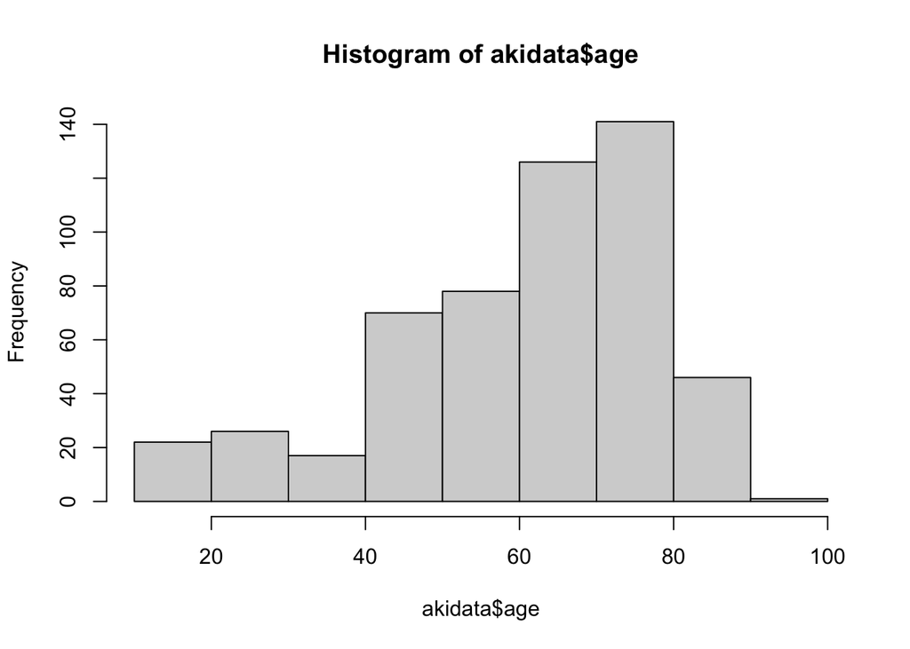

```r
hist(akidata$age)
```

# Task 3

Produce another histogram of the patient ages. Ensure the x labels and plot title are well specified.

*Answer:*

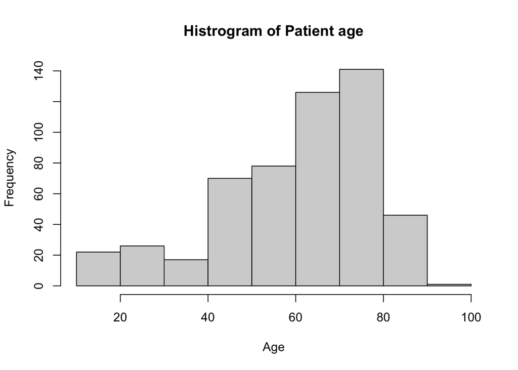

```r
hist(akidata$age, main = "Histrogram of Patient age", xlab = "Age")
```

******

# Task 4

Produce a histogram of the patient weights. Set the number of bins to 15. Ensure the x labels and plot title are well specified.

*Answer:*

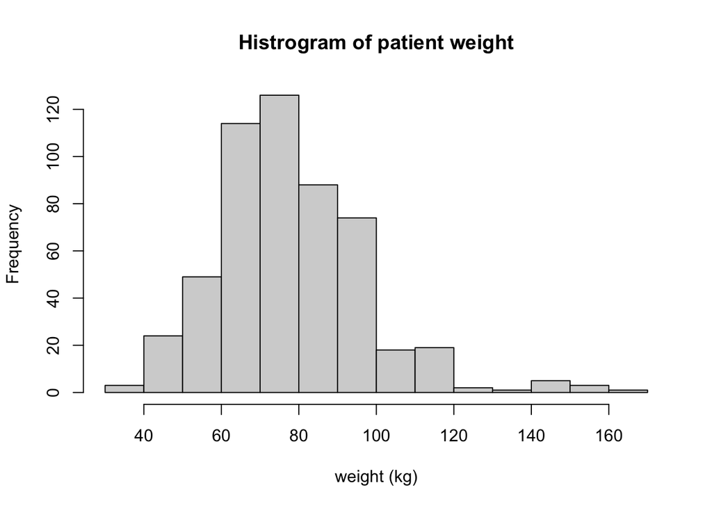

```r
patientWeightHist <- hist(akidata$weight, breaks = 15, main = "Histrogram of patient weight", xlab = "weight (kg)")
```

******

# Task 5

The y-axis is giving the frequency in each bin. Instead of the frequency, we may prefer to have the y-axis measure the probability density (proportions). Using `help(hist)` as a guide, produce a histogram of patient age where the y-axis is in terms of the probability density.

*Answer:*

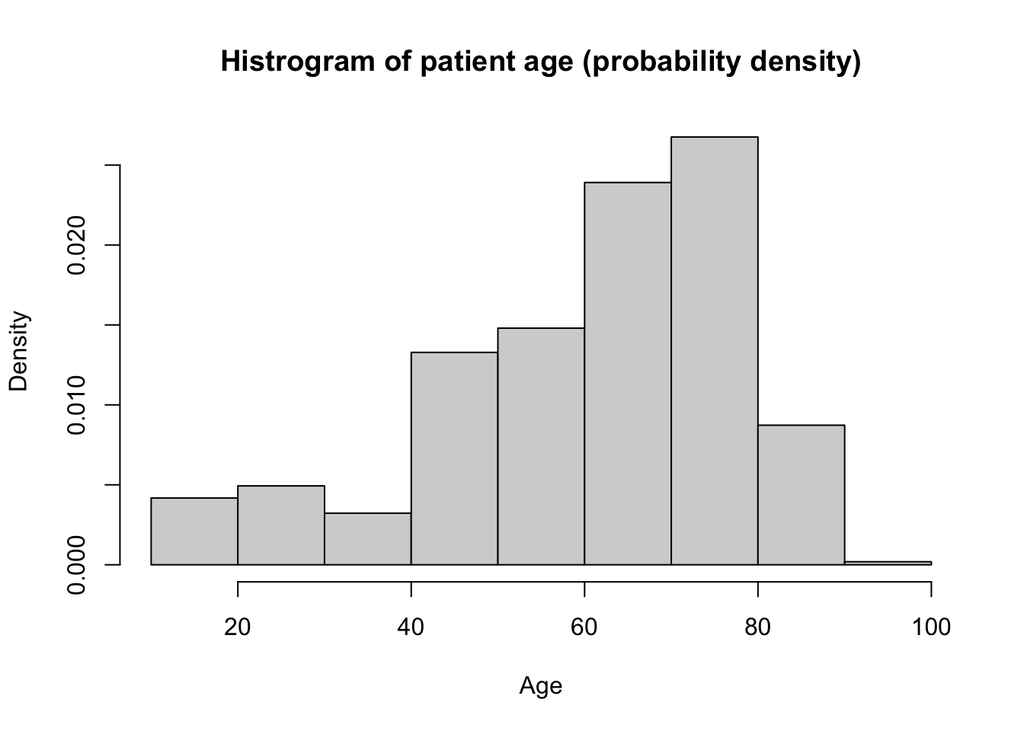

```r
hist(akidata$age, freq = FALSE, main = "Histrogram of patient age (probability density)", xlab  = "Age")
```

# Task 6

Obtain a list of the break points and frequencies for the histogram of weight (with 15 break points). Hint 1: use `help(hist)` as a guide. Hint 2: you do not need to provide a plot.

```r
patientWeightHist$breaks
```

```
##  [1]  30  40  50  60  70  80  90 100 110 120 130 140 150 160 170
```

```r
patientWeightHist$counts
```

```
##  [1]   3  24  49 114 126  88  74  18  19   2   1   5   3   1
```

# Task 7

Plot a boxplot of the patient weights. Ensure you include a title and y-axis label.

*Answer:*

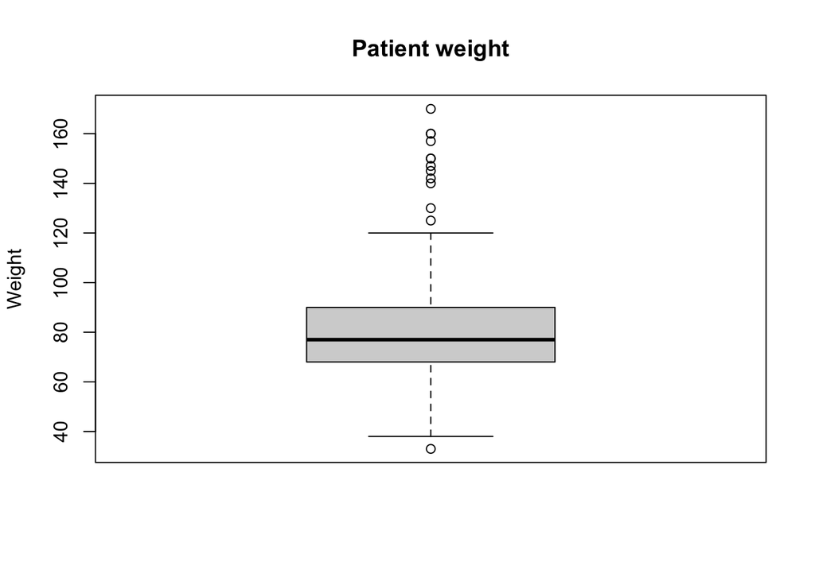

```r
boxplot(akidata$weight, ylab = "Weight", main = "Patient weight")
```

******

# Task 8

Plot boxplots of the patient weight by sex. That is, the boxplot of weight for males should be beside the boxplot of weight for females. Ensure the x and y labels are well specified.

*Answer:*

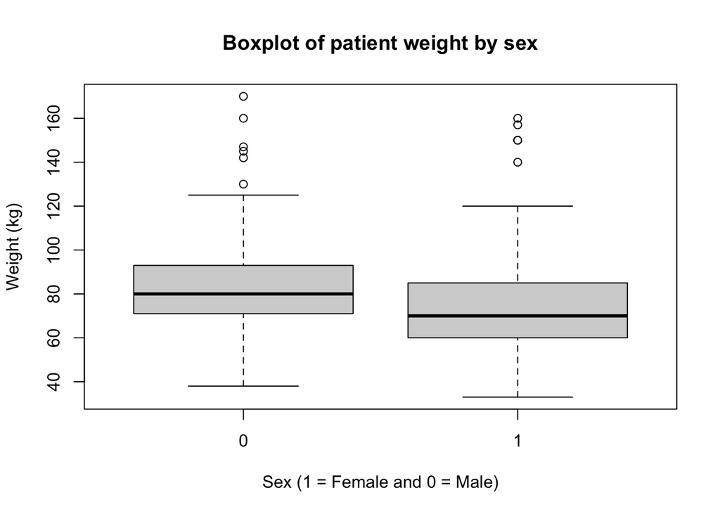

```r
boxplot(akidata$weight ~ akidata$sex, ylab = "Weight (kg)", xlab = "Sex (1 = Female and 0 = Male)", main = "Boxplot of patient weight by sex")
```